# Test a Perceptual Phenomenon

```
                                 Saravanan Natarajan
```

Analyzing the Stroop Effect:

Stroop Effect is an experiment you are required to say the color of the word, not what the word says. For example, for the word, RED, you should say "Blue." There will be two set of experiments to collect data from congruent and incongruent words and analyse those results.

(1) What is the independent variable? What is the dependent variable?

The independent variable: The variable you have control over, what you can choose and manipulate (congruent and incongruent words)

The dependent variable: The A dependent variable is what you measure in the experiment and what is affected during the experiment (response time)

(2) What is an appropriate set of hypotheses for this task? Specify your null and alternative hypotheses, and clearly define any notation used. Justify your choices.

(2a)Hypotheses

μi - Mean of incongruent population's response time. μc - Mean of congruent population's response time.

Ho - Null Hypothesis: There is no significant difference in the population average response time in viewing the congruent words vs viewing the incongruent words.

μi - μc = 0

Ha - Alternative Hypothesis: There is a significant difference, positive or negative, in the population average response times.

( μi - μc ≠ 0 )

(2b)Statistical test

The paired sample t-test, sometimes called the dependent sample t-test, is a statistical procedure used to determine whether the mean difference between two sets of observations is zero.

Following assumptions were required:

- Interval or ratio scale of measurement (approximately interval)
- Random sampling from a defined population
- Samples (here the sample size is less than 30) or sets of data used to produce the difference scores are linked in the population through repeated measurement, natural association, or matching
- Scores are normally distributed in the population; difference scores are normally distributed
- Each participant is exposed to both conditions and tested for each so the structure of the data is dependent samples.

```python
%matplotlib inline
import pandas as pd
import matplotlib.pyplot as plt
import plotly.plotly as py
import seaborn as sns
import scipy.stats as stats
```

```python
dfStroop = pd.read_csv('stroopdata.csv')
dfStroop
```

|  | Congruent | Incongruent |
| --- | --- | --- |
| 0 | 12.079 | 19.278 |
| 1 | 16.791 | 18.741 |
| 2 | 9.564 | 21.214 |
| 3 | 8.630 | 15.687 |
| 4 | 14.669 | 22.803 |
| 5 | 12.238 | 20.878 |
| 6 | 14.692 | 24.572 |
| 7 | 8.987 | 17.394 |
| 8 | 9.401 | 20.762 |
| 9 | 14.480 | 26.282 |
| 10 | 22.328 | 24.524 |
| 11 | 15.298 | 18.644 |
| 12 | 15.073 | 17.510 |
| 13 | 16.929 | 20.330 |
| 14 | 18.200 | 35.255 |
| 15 | 12.130 | 22.158 |
| 16 | 18.495 | 25.139 |
| 17 | 10.639 | 20.429 |
| 18 | 11.344 | 17.425 |
| 19 | 12.369 | 34.288 |
| 20 | 12.944 | 23.894 |
| 21 | 14.233 | 17.960 |
| 22 | 19.710 | 22.058 |
| 23 | 16.004 | 21.157 |

```python
dfStroop.info()
```

```
<class 'pandas.core.frame.DataFrame'>
RangeIndex: 24 entries, 0 to 23
Data columns (total 2 columns):
Congruent      24 non-null float64
Incongruent    24 non-null float64
dtypes: float64(2)
memory usage: 464.0 bytes
```

(3) Report some descriptive statistics regarding this dataset. Include at least one measure of central tendency and at least one measure of variability. The name of the data file is 'stroopdata.csv'.

```python
dfStroop.describe()
```

|  | Congruent | Incongruent |
| --- | --- | --- |
| count | 24.000000 | 24.000000 |
| mean | 14.051125 | 22.015917 |
| std | 3.559358 | 4.797057 |
| min | 8.630000 | 15.687000 |
| 25% | 11.895250 | 18.716750 |
| 50% | 14.356500 | 21.017500 |
| 75% | 16.200750 | 24.051500 |
| max | 22.328000 | 35.255000 |

Congruent Mean = 14.051125 Incongruent Mean = 22.015917 Congruent Standard Deviation = 3.559358 Incongruent Standard Deviation = 4.797057

(4) Provide one or two visualizations that show the distribution of the sample data. Write one or two sentences noting what you observe about the plot or plots.

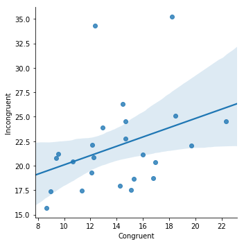

```python
sns.lmplot(x='Congruent', y='Incongruent', data=dfStroop)
plt.show()
```

lmplot displays the linear trend between Incongruent and Congruent. The regression line shows the probability will change when multiple readings were taken.

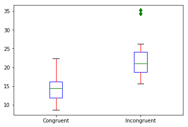

```python
color = dict(boxes='Blue', whiskers='Red', medians='Green', caps='Black')
dfStroop.plot.box(color = color, sym = 'gd')
```

Boxplot displays the median of Incongruent is higher than Congruent. It means, participant’s take more time to say out loud the color of the ink in which the word is printed.

(5) Now, perform the statistical test and report your results. What is your confidence level or Type I error associated with your test? What is your conclusion regarding the hypotheses you set up? Did the results match up with your expectations? **Hint:** Think about what is being measured on each individual, and what statistic best captures how an individual reacts in each environment.

```python
# Calculte the mean of each test
congurent_mean = dfStroop['Congruent'].mean()
incongurant_mean = dfStroop['Incongruent'].mean()

#point estimate of μi - μc -> PE (in seconds)
point_estimate = congurent_mean - incongurant_mean

# Calculate Square of Sums of difference of sample means
ssd = sum(((dfStroop['Congruent']-dfStroop['Incongruent'])-point_estimate)**2)

# Calculate the variance of difference
vd = ssd / (24 -1)

# Calculate Standard Deviation of Differences
sdd = vd ** (1/2)

#  calculate the t-statistic for the difference
tstatistic = point_estimate / ( sdd / ( 24 ** (1/2) ) )

# Calculate the Degrees of Freedom (n -1)
df = 23

# Calculte the chances of seeing a result as extreme
# as the one we observed (known as the p-value)
pvalue = stats.t.cdf(x = tstatistic, df = 23 ) * 2

# Clacute t-critical for alpha level 0.005 (aiming to 99% confidence level)
alpha = 0.005
tcritical = stats.t.ppf(q=alpha, df=23)

print("t-critical values :  tc  =", -tcritical, tcritical)
print("t-Statistic(df) : t(23) =", tstatistic)
print("p-value : p =", pvalue)
```

```
t-critical values :  tc  = 2.80733568377 -2.80733568377
t-Statistic(df) : t(23) = -8.02070694411
p-value : p = 4.10300058571e-08
```

(6) Optional: What do you think is responsible for the effects observed? Can you think of an alternative or similar task that would result in a similar effect? Some research about the problem will be helpful for thinking about these two questions!

People recognise the color first and then started reading the words. The longer word takes more time read and recognise the color compared to the shorter words and recognising the color. Similar task is identifying the color using the Color Blind Tests.

Reference:

1. https://labwrite.ncsu.edu/po/variablespo.htm
2. http://hamelg.blogspot.sg/2015/11/python-for-data-analysis-part-24.html
3. https://github.com/rouseguy/intro2stats
4. http://greenteapress.com/thinkstats/thinkstats.pdf
5. https://www.statisticssolutions.com/manova-analysis-paired-sample-t-test/
6. http://www.allaboutvision.com/eye-exam/color-blind-tests.htm
7. http://www.psychology.emory.edu/clinical/bliwise/Tutorials/TOM/meanstests/assump.htm)